# Project Course 2

## Background

An online news portal aims to expand its business by acquiring new subscribers. Every visitor to the website takes certain actions based on their interest. The company plans to analyze these interests and wants to determine whether a new feature will be effective or not. Companies often analyze users' responses to two variants of a product to decide which of the two variants is more effective. This experimental technique is known as a/b testing that is used to determine whether a new feature attracts users based on a chosen metric.

## Overview

Suppose you are hired as a Data Scientist in E-news Express. The design team of the company has created a new landing page. You have been assigned the task to decide whether the new landing page is more effective to gather new subscribers. Suppose you randomly selected 100 users and divided them equally into two groups. The old landing page is served to the first group (control group) and the new landing page is served to the second group (treatment group). Various data about the customers in both groups are collected in 'abtest.csv'. Perform the statistical analysis to answer the following questions using the collected data.

## Key Questions

1. Explore the dataset and extract insights using Exploratory Data Analysis.
2. Do the users spend more time on the new landing page than the old landing page?
3. Is the conversion rate (the proportion of users who visit the landing page and get converted) for the new page greater than the conversion rate for the old page?
4. Does the converted status depend on the preferred language?
5. Is the mean time spent on the new page same for the different language users?

## Data Description

1. user_id - This represents the user ID of the person visiting the website.
2. group - This represents whether the user belongs to the first group (control) or the second group (treatment).
3. landing_page - This represents whether the landing page is new or old.
4. time_spent_on_the_page - This represents the time (in minutes) spent by the user on the landing page.
5. converted - This represents whether the user gets converted to a subscriber of the news portal or not.
6. language_preferred - This represents the language chosen by the user to view the landing page.

```python
# import the important packages
import pandas as pd
# library used for data manipulation and analysis

import numpy as np  # library used for working with arrays

import matplotlib.pyplot as plt  # library for visualization

import seaborn as sns  # library for visualization

%matplotlib inline

import scipy.stats as stats  # this library contains a large number of probability distributions as well as a growing library of statistical functions
from scipy.stats import uniform
from scipy.stats import norm
from scipy.stats import expon
from scipy.stats import binom
from scipy.stats import ttest_1samp
from scipy.stats import ttest_ind
from scipy.stats import ttest_rel
from statsmodels.stats.proportion import proportions_ztest
from scipy.stats import chi2
from scipy.stats import f
from scipy.stats import chi2_contingency
from scipy.stats import levene
from scipy.stats import f_oneway
from statsmodels.stats.multicomp import pairwise_tukeyhsd
```

```python
#Loading and Viewing of Dataset

book=pd.read_csv('abtest.csv')

# copying data to another varaible to avoid any changes to original data

bc = book.copy()

# looking at head (5 observations)

bc.head()
```

|  | user_id | group | landing_page | time_spent_on_the_page | converted | language_preferred |
| --- | --- | --- | --- | --- | --- | --- |
| 0 | 546592 | control | old | 3.48 | no | Spanish |
| 1 | 546468 | treatment | new | 7.13 | yes | English |
| 2 | 546462 | treatment | new | 4.40 | no | Spanish |
| 3 | 546567 | control | old | 3.02 | no | French |
| 4 | 546459 | treatment | new | 4.75 | yes | Spanish |

```python
bc.shape
```

```
(100, 6)
```

The dataset has 100 rows and 6 columns

```python
bc.info()
```

```
<class 'pandas.core.frame.DataFrame'>
RangeIndex: 100 entries, 0 to 99
Data columns (total 6 columns):
 #   Column                  Non-Null Count  Dtype
---  ------                  --------------  -----
 0   user_id                 100 non-null    int64
 1   group                   100 non-null    object
 2   landing_page            100 non-null    object
 3   time_spent_on_the_page  100 non-null    float64
 4   converted               100 non-null    object
 5   language_preferred      100 non-null    object
dtypes: float64(1), int64(1), object(4)
memory usage: 4.8+ KB
```

Observations

All columns have 100 rows  
group, landing_page, converted and language_preferred should be categorical variables

## Data Preprocessing

### Fixing of Datatypes

```python
#group column should be converted to categorical type
#landing_page column should be converted to categorical type
#converted column should be converted to categorical type
#language_preferred column should be converted to categorical type


bc['group']=bc.group.astype('category')
bc['landing_page']=bc.landing_page.astype('category')
bc['converted']=bc.converted.astype('category')
bc['language_preferred']=bc.language_preferred.astype('category')
```

```python
bc.info()
```

```
<class 'pandas.core.frame.DataFrame'>
RangeIndex: 100 entries, 0 to 99
Data columns (total 6 columns):
 #   Column                  Non-Null Count  Dtype
---  ------                  --------------  -----
 0   user_id                 100 non-null    int64
 1   group                   100 non-null    category
 2   landing_page            100 non-null    category
 3   time_spent_on_the_page  100 non-null    float64
 4   converted               100 non-null    category
 5   language_preferred      100 non-null    category
dtypes: category(4), float64(1), int64(1)
memory usage: 2.6 KB
```

There are 4 categorical, 1 integer and 1 numerical columns

### Summary of the Data

```python
bc.describe().T
```

|  | count | mean | std | min | 25% | 50% | 75% | max |
| --- | --- | --- | --- | --- | --- | --- | --- | --- |
| user_id | 100.0 | 546517.0000 | 52.295779 | 546443.00 | 546467.75 | 546492.500 | 546567.2500 | 546592.00 |
| time_spent_on_the_page | 100.0 | 5.3778 | 2.378166 | 0.19 | 3.88 | 5.415 | 7.0225 | 10.71 |

The mean and median are very close indicting a normally distributed data  
There isn't a large difference between the 3rd quartile and max values

```python
bc.describe(exclude='number').T
```

|  | count | unique | top | freq |
| --- | --- | --- | --- | --- |
| group | 100 | 2 | control | 50 |
| landing_page | 100 | 2 | new | 50 |
| converted | 100 | 2 | yes | 54 |
| language_preferred | 100 | 3 | French | 34 |

```python
#Making a list of all catrgorical variables
cat_col=['group','landing_page','converted','language_preferred']

#Printing number of count of each unique value in each column
for column in cat_col:
    print(bc[column].value_counts())
    print('-'*50)
```

```
control      50
treatment    50
Name: group, dtype: int64
--------------------------------------------------
new    50
old    50
Name: landing_page, dtype: int64
--------------------------------------------------
yes    54
no     46
Name: converted, dtype: int64
--------------------------------------------------
French     34
Spanish    34
English    32
Name: language_preferred, dtype: int64
--------------------------------------------------
```

#### Observations

There are more yes than no  
French and Spanish have the same count, while English is lower

### Missing Values Check

```python
# checking missing values

bc.isna().sum()
```

```
user_id                   0
group                     0
landing_page              0
time_spent_on_the_page    0
converted                 0
language_preferred        0
dtype: int64
```

# EDA

## Numerical Variables

```python
# function to plot a boxplot and a histogram along the same scale.

def histogram_boxplot(data, feature, figsize=(12, 7), kde=False, bins=None):
    f2, (ax_box2, ax_hist2) = plt.subplots(
        nrows=2,  # Number of rows of the subplot grid= 2
        sharex=True,  # x-axis will be shared among all subplots
        gridspec_kw={"height_ratios": (0.25, 0.75)},
        figsize=figsize,
    )  # creating the 2 subplots
    sns.boxplot(
        data=data, x=feature, ax=ax_box2, showmeans=True, color="violet"
    )  # boxplot will be created and a star will indicate the mean value of the column
    sns.histplot(
        data=data, x=feature, kde=kde, ax=ax_hist2, bins=bins, palette="winter"
    ) if bins else sns.histplot(
        data=data, x=feature, kde=kde, ax=ax_hist2
    )  # For histogram
    ax_hist2.axvline(
        data[feature].mean(), color="green", linestyle="--"
    )  # Add mean to the histogram
    ax_hist2.axvline(
        data[feature].median(), color="black", linestyle="-"
    )  # Add median to the histogram
```

### Observations on Time Spent on Page

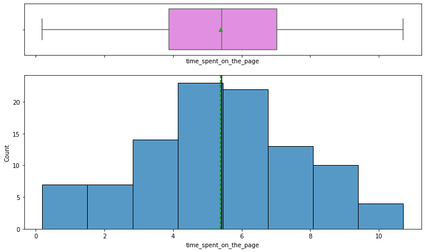

```python
histogram_boxplot(bc, 'time_spent_on_the_page')
```

#### Observatuons

1. The mean and median are very close ~5
2. There are no outliers in the data
3. The data is reasonably even

## Categorical Variables

```python
# function to create labeled barplots


def labeled_barplot(data, feature, perc=False, n=None):
    """
    Barplot with percentage at the top

    data: dataframe
    feature: dataframe column
    perc: whether to display percentages instead of count (default is False)
    n: displays the top n category levels (default is None, i.e., display all levels)
    """

    total = len(data[feature])  # length of the column
    count = data[feature].nunique()
    if n is None:
        plt.figure(figsize=(count + 1, 5))
    else:
        plt.figure(figsize=(n + 1, 5))

    plt.xticks(rotation=90, fontsize=15)
    ax = sns.countplot(
        data=data,
        x=feature,
        palette="Paired",
        order=data[feature].value_counts().index[:n].sort_values(),
    )

    for p in ax.patches:
        if perc == True:
            label = "{:.1f}%".format(
                100 * p.get_height() / total
            )  # percentage of each class of the category
        else:
            label = p.get_height()  # count of each level of the category

        x = p.get_x() + p.get_width() / 2  # width of the plot
        y = p.get_height()  # height of the plot

        ax.annotate(
            label,
            (x, y),
            ha="center",
            va="center",
            size=12,
            xytext=(0, 5),
            textcoords="offset points",
        )  # annotate the percentage

    plt.show()  # show the plot
```

### Observations on Conversion status

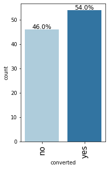

```python
plt.figure(figsize=(10,7))
labeled_barplot(bc, 'converted', perc=True)
```

#### Observations

There are more converted customers than non-converted customers

### Observations on Preferred Language

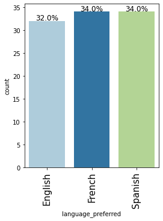

```python
plt.figure(figsize=(10,7))
labeled_barplot(bc, 'language_preferred', perc=True)
```

#### Observations

Both French and Spanish have equal levels of preference, with English being lower

## Multivariate Analysis

### Check for various trends across the categories

#### Mean Time w.r.t Group

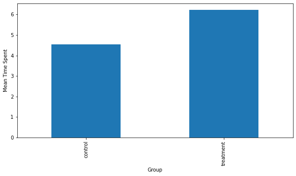

```python
# getting the mean of the time spent across the groups
bcgg = bc.groupby(by=['group'])['time_spent_on_the_page'].mean()
bcgg.plot(kind='bar',ylabel='Mean Time Spent',xlabel='Group',figsize=(10,5))
```

#### Observations

The treatment group spent a much higher mean time.

#### Mean Time w.r.t Landing Page

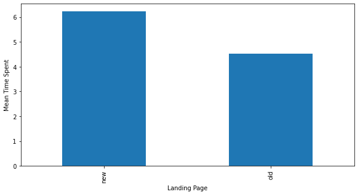

```python
# getting the mean of the time spent across the landing page
bcgl = bc.groupby(by=['landing_page'])['time_spent_on_the_page'].mean()
bcgl.plot(kind='bar',ylabel='Mean Time Spent',xlabel='Landing Page',figsize=(10,5))
```

#### Observations

The new page incurred a much higher mean time

#### Mean Time w.r.t Conversion Status

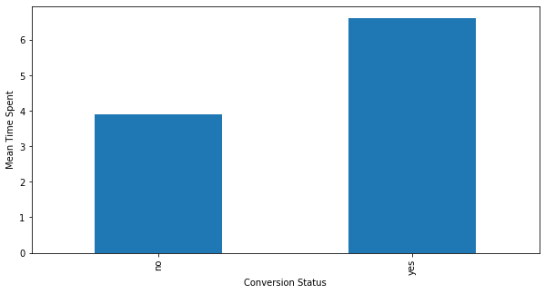

```python
# getting the mean of the time spent across the conversion status
bcgc = bc.groupby(by=['converted'])['time_spent_on_the_page'].mean()
bcgc.plot(kind='bar',ylabel='Mean Time Spent',xlabel='Conversion Status',figsize=(10,5))
```

#### Observations

The customers that converted spent a much higher mean time on the pages.

#### Mean Time w.r.t Language Preference

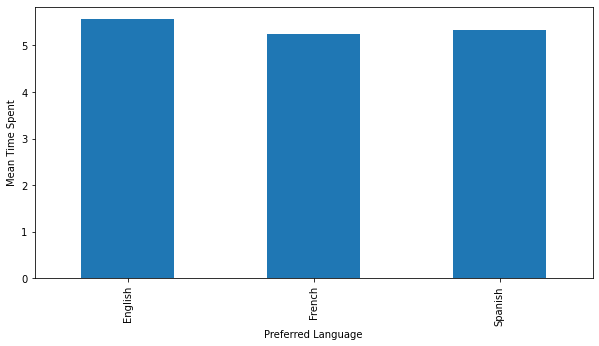

```python
# getting the mean of the time spent across the language preference
bcgpl = bc.groupby(by=['language_preferred'])['time_spent_on_the_page'].mean()
bcgpl.plot(kind='bar',ylabel='Mean Time Spent',xlabel='Preferred Language',figsize=(10,5))
```

#### Observations

1. English had the highest mean time spent
2. However, the difference between mean times isn’t very large

```python
# getting the mean of the time_spent across the group, conversion status and language preference
bcggcl = bc.groupby(by=['group','converted','language_preferred',])['time_spent_on_the_page'].mean()
print(bcggcl)
```

```
group      converted  language_preferred
control    no         English               1.776000
                      French                3.669286
                      Spanish               3.688000
           yes        English               5.671818
                      French                7.300000
                      Spanish               6.457143
treatment  no         English               5.506667
                      French                4.400000
                      Spanish               4.660000
           yes        English               7.358000
                      French                6.945000
                      Spanish               6.476364
Name: time_spent_on_the_page, dtype: float64
```

# Hypothesis Testing

## Time Spent on Landing Page

Hypothesis statements  
let μ be the mean time spent

μ0 = time spent on old landing page  
μ1 = time spent on new landing page

we will test null hypothesis  
H0: μ0 > μ1

against the alternative hypothesis  
H1: μ0 < μ1

#### Assumptions

```
landing_page
new    6.2
old    4.5
Name: time_spent_on_the_page, dtype: float64
```

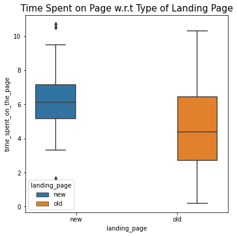

```python
#get the means for the two samples
print(str(round(bc.groupby('landing_page')['time_spent_on_the_page'].mean(),1)))

#draw boxplot for visualization
fig,ax=plt.subplots(figsize=(6,6))
a=sns.boxplot(x='landing_page',y='time_spent_on_the_page',data=bc,hue='landing_page')
a.set_title('Time Spent on Page w.r.t Type of Landing Page',fontsize=15)
plt.show()
```

```python
test_stat,p_value = f_oneway(bc.loc[bc['landing_page']=='old','time_spent_on_the_page'],
                               bc.loc[bc['landing_page']=='new','time_spent_on_the_page'])

print('The p-value is '+str(p_value))
```

```
The p-value is 0.0002632247056189993
```

## Conversion Rate Comparison

```
conversion rate for old landing page is  0.42
conversion rate for new landing page is  0.66
```

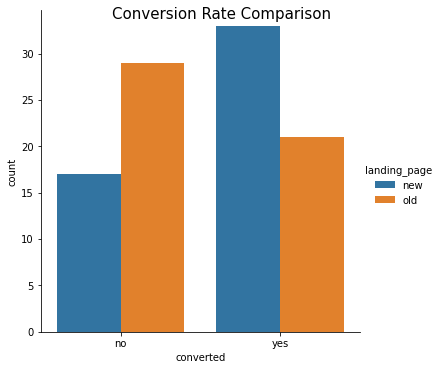

```python
#calculate conversion rate

#conversion rate for old landing page
conrateold = (convrttotal['yes','old'] / 50)
print('conversion rate for old landing page is ',conrateold)

#conversion rate for new landing page
conratenew = (convrttotal['yes','new'] / 50)
print('conversion rate for new landing page is ',conratenew)

#draw boxplot for visualization
a=sns.catplot(x="converted", hue="landing_page", kind="count", data=bc)
a.fig.suptitle("Conversion Rate Comparison",fontsize=15)
plt.show()
```

Hypothesis Statements

Let μ1 be the old landing page conversion rate  
Let μ2 be the new landing page conversion rate

we will test null hypothesis  
H0: μ1 = μ2

against the alternative hypothesis  
H1: μ2 >= μ1

```python
#set count of converted customers
converted=np.array([21,33])

#sample size
sample_size=np.array([50,50])

#p-value
test_stat,p_value=proportions_ztest(converted,sample_size)
print('The p-value is',p_value)
```

```
The p-value is 0.016052616408112556
```

#### Insight

As the p-value is less than the level of significance, I reject the null hypothesis.  
There is not enough statistical evidence to say that the conversion rate on the new landing page is the same as the conversion rate of the old landing page.

## Conversion Status and Language Preference

```python
#creating a contingency table
conttab=pd.crosstab(bc['converted'],bc['language_preferred'],margins=False)
print(conttab)
```

```
language_preferred  English  French  Spanish
converted
no                       11      19       16
yes                      21      15       18
```

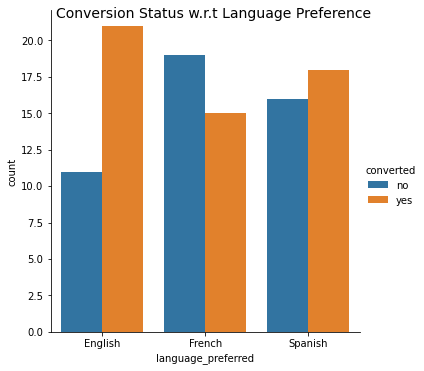

```python
#draw boxplot for visualization
a=sns.catplot(x="language_preferred", hue="converted", kind="count", data=bc)
a.fig.suptitle("Conversion Status w.r.t Language Preference",fontsize=14)
plt.show()
```

Hypothesis statements

we will test null hypothesis  
H0: Converted status is independent of language preference

against the alternative hypothesis  
H1: Converted status is dependent on language preference

```python
chi,p_value,dof,expected=chi2_contingency(conttab.drop('Spanish',axis=1))
print('p-value for Spanish is',p_value)
chi,p_value,dof,expected=chi2_contingency(conttab.drop('English',axis=1))
print('p-value for English is',p_value)
chi,p_value,dof,expected=chi2_contingency(conttab.drop('French',axis=1))
print('p-value for French is',p_value)
```

```
p-value for Spanish is 0.1319632813072201
p-value for English is 0.6274768949614127
p-value for French is 0.4254784093951157
```

## Language on Landing Page Comparison

Hypothesis Statements let μ be the mean time spent on the new page

Hypothesis statements let μ be the means let μ1,μ2 and μ3 be English, Spanish and French respectively

we will test null hypothesis  
H0: one of the means is different

against the alternative hypothesis  
H1: μ1 = μ2 = μ3

```python
#create a new dataframe with the new landing page as the only type of landing page
landpgnew=bc[bc['landing_page'].isin(['new'])]
landpgnew.head()
```

|  | user_id | group | landing_page | time_spent_on_the_page | converted | language_preferred |
| --- | --- | --- | --- | --- | --- | --- |
| 1 | 546468 | treatment | new | 7.13 | yes | English |
| 2 | 546462 | treatment | new | 4.40 | no | Spanish |
| 4 | 546459 | treatment | new | 4.75 | yes | Spanish |
| 6 | 546448 | treatment | new | 5.25 | yes | French |
| 8 | 546461 | treatment | new | 10.71 | yes | French |

```
language_preferred
English    6.7
French     6.2
Spanish    5.8
Name: time_spent_on_the_page, dtype: float64
```

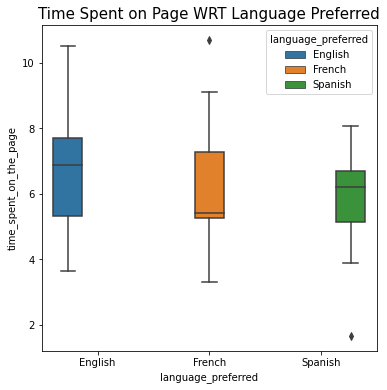

```python
#get the sample means and std for the two samples
print(str(round(landpgnew.groupby('language_preferred')['time_spent_on_the_page'].mean(),1)))

#draw boxplot for visualization
fig,ax=plt.subplots(figsize=(6,6))
a=sns.boxplot(x='language_preferred',y='time_spent_on_the_page',data=landpgnew,hue='language_preferred')
a.set_title('Time Spent on Page WRT Language Preferred',fontsize=15)
plt.show()
```

## Tests for Assumptions on Data

### Shapiro Wilkes Test (Normality Test)

We will test null hypothesis

H0: time spent on the landing page follows a normal distribution

against the alternative hypothesis

H1: time spent on the landing page does not follow a normal distribution

```python
#assumption 1: normality of distribution

#find the p-value
w,p_value=stats.shapiro(landpgnew['time_spent_on_the_page'])
print('The p-value is ',p_value)
```

```
The p-value is  0.8040016293525696
```

#### Insight

As the p-value is higher than the level of significance, I fail to reject the null hypothesis.  
Therefore the data follows a normal distribution.

### Levene test (Equality test)

we will test null hypothesis

H0: all population variances are equal

against the alternative hypothesis

H1: at least one population variance is different

```python
#assumption 2: equality of variance


statistic,p_value=levene(landpgnew['time_spent_on_the_page'][landpgnew['language_preferred']=='English'],
                               landpgnew['time_spent_on_the_page'][landpgnew['language_preferred']=='French'],
                               landpgnew['time_spent_on_the_page'][landpgnew['language_preferred']=='Spanish'])

#find the p-value
print('The p-value is ',p_value)
```

```
The p-value is  0.46711357711340173
```

### Insight

As the p-value is higher than the level of significance, I fail to reject the null hypothesis.  
Therefore the samples have equal variance.

Tests whether assumptions are satisfied:

1. Population are normally distributed, verified using the Shapiro-Wilkes test
2. Population variances are equal, verified using the Levene test
3. We are told that the sample is random

```python
#p value of anova test

#perform one-way anova test
test_stat,p_value = f_oneway(landpgnew.loc[landpgnew['language_preferred']=='Spanish','time_spent_on_the_page'],
                               landpgnew.loc[landpgnew['language_preferred']=='French','time_spent_on_the_page'],
                               landpgnew.loc[landpgnew['language_preferred']=='English','time_spent_on_the_page'])

print('The p-value is'+str(p_value))
```

```
The p-value is0.43204138694325955
```

### Tukey HSD (Multiple Comparison Test)

we will test null hypothesis

H0: μ1 ≠ μ2 and μ1 ≠ μ3 and μ2 ≠ μ3

against the alternative hypothesis

H1: μ1 = μ2 and μ1 = μ3 and μ2 = μ3

```python
#perform multiple pairwise comparison
m_comp = pairwise_tukeyhsd(endog = landpgnew['time_spent_on_the_page'],groups = landpgnew['language_preferred'],alpha=0.05)
print(m_comp)
```

```
 Multiple Comparison of Means - Tukey HSD, FWER=0.05
=====================================================
 group1  group2 meandiff p-adj   lower  upper  reject
-----------------------------------------------------
English  French  -0.4673 0.7259 -2.0035  1.069  False
English Spanish  -0.8285  0.401 -2.3647 0.7078  False
 French Spanish  -0.3612  0.816  -1.874 1.1516  False
-----------------------------------------------------
```

# Conclusion and Recommendation

## Conclusion

I analysed the 2 sets of customers that were given the pages to explore. From the analysis, I was able to determine the following:

1. The conversion rate is about 54%, which is reasonably high.
2. English is the least preferred language. However, the difference between it and the other languages isn’t significant.
3. The treatment group spent a higher time on their pages
4. More time was spent on the new landing page
5. The converted customers spent significantly more time on their pages
6. The conversion rate for the new landing page is higher than the conversion rate for the old landing page
7. The conversion rate doesn’t depend on the languages chosen meaning that the new page is fine across all the languages

## Recommendation

Based on the analysis, there are following recommendations that can help the business grow:

1. The new landing page should be adopted as it is seen to be preferred.
2. The old landing page shouldn’t be thrown out, but more work should be done to get customers to convert to the new landing page.
3. As there is no issue with the language on the pages, all 3 languages should still be kept on
4. However, there should be an investigation into why English has the highest rate of conversion amongst the 3 languages
5. The feature has proven to be effective. It should be implemented. However, I suggest a sensitization program for reluctant customers so that they are not lost as customers